# Predicting Outpatient Consultation Duration

Capstone Project Summary — Hangu Outpatient Oncology Clinic

Author

Ariana Butina

Published

July 2, 2026

## Motivation

Time-Driven Activity-Based Costing (TDABC) needs one core input per activity: **how long it takes.** This project builds two machine learning models on 6,637 historical outpatient oncology consultations to predict exactly that — supporting a master’s thesis applying TDABC to outpatient scheduling.

- **Classifier** — will this consultation be *long* or *short*, relative to the clinic’s own history?
- **Regressor** — how many minutes will this consultation take?

## System Architecture

```
GitHub  ──▶  Render (FastAPI + scikit-learn)  ◀── fetch() ──  Vercel (React + Recharts)
  │
  └──▶  ml/ pipeline: load → clean → engineer → split → tune → evaluate → persist
```

- **ML pipeline**: pandas, scikit-learn, XGBoost (compared, not selected) — reproducible, leakage-audited, versioned artifacts
- **Backend**: FastAPI, serving both models behind separate, documented REST endpoints
- **Frontend**: React + Vite + TypeScript + Tailwind + Recharts, with a live prediction form and an interactive results dashboard
- **Deployment**: GitHub → Render (backend) and GitHub → Vercel (frontend), both auto-deploying on push

## Key Results

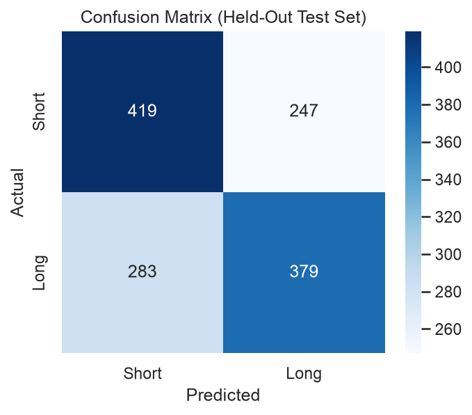

Figure 1: Classification: confusion matrix (held-out test set)

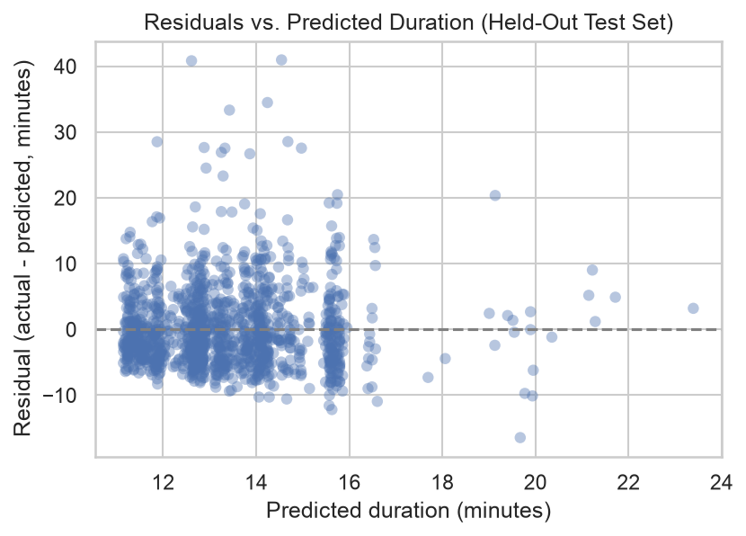

Figure 2: Regression: residuals vs. predicted (held-out test set)

| Task | Metric | Value |
| --- | --- | --- |
| Classification | Accuracy | 0.601 |
| Classification | ROC-AUC | 0.632 |
| Regression | MAE | 4.41 min |
| Regression | R² | 0.066 |

**Headline finding:** across both tasks, **patient visit history** (`Visit.No`, `IsRepeatVisit`) is by far the strongest predictor — well ahead of diagnosis flags or calendar/scheduling context. For TDABC, this points toward visit-history-based patient segmentation as the more promising basis for outpatient cost-driver estimation, rather than segmentation by day, month, or diagnosis.

**Honest limitation:** the regression model explains only a small share of duration variance (R² ≈ 0.07); the available scheduling fields cannot capture the clinical complexity that likely drives most of a consultation’s actual length. Predictions should inform scheduling and capacity planning, not clinical decisions.

## Live Demo

- **Frontend:** frontend-psi-seven-76.vercel.app
- **Backend API docs:** hangu-consult-backend.onrender.com/docs
- **Source code:** github.com/arianabutina-source/hangu-consult-time-ml

## Takeaway

A fully reproducible, leakage-audited ML pipeline — trained, evaluated once and honestly, served through a documented API, and presented through an interactive dashboard — turns a single clinic’s scheduling data into an actionable signal for TDABC-style cost-driver planning, while being transparent about exactly how far that signal goes.